# Лабораторна робота 4

Anna Varych, KN-23-1, 2024

2024-11-28

## Постановка задачі

Випадкова величина $X$ має заданий закон розподілу, вектор параметрів якого відомий. Необхідно згенерувати вибірку випадкової величини $X = (x_1, \dots, x_n)$, спочатку об’єму $n = 50$, обчислити оцінку вектора параметрів розподілу та перевірити гіпотезу щодо нормальності розподілу за допомогою статистичних критеріїв.

### Опис рівномірного розподілу

Для випадкової величини $X$ з рівномірним розподілом на відрізку $[a, b]$, функція щільності ймовірності виглядає наступним чином:

$f(x) = \frac{1}{b - a}, \quad \text{для } a \leq x \leq b$

де $a = 0$, $b = 1$.

## Розв’язок задачі

### Генерація вибірки

Спочатку згенеруємо вибірки з рівномірного розподілу для двох випадків: для $n = 50$ та $n = 1000$.

```r
# Генерація вибірки з рівномірного розподілу
set.seed(123)
n50 <- runif(50, min = 0, max = 1)
n1000 <- runif(1000, min = 0, max = 1)

# Перегляд перших 5 елементів вибірок
head(n50)
```

```
[1] 0.2875775 0.7883051 0.4089769 0.8830174 0.9404673 0.0455565
```

```r
head(n1000)
```

```
[1] 0.04583117 0.44220007 0.79892485 0.12189926 0.56094798 0.20653139
```

```r
# Оцінка параметрів для n = 50
mean50 <- mean(n50)
var50 <- var(n50)

# Оцінка параметрів для n = 1000
mean1000 <- mean(n1000)
var1000 <- var(n1000)

mean50
```

```
[1] 0.520091
```

```r
var50
```

```
[1] 0.08660557
```

```r
mean1000
```

```
[1] 0.4947364
```

```r
var1000
```

```
[1] 0.08129791
```

```r
# Перевірка на нормальність для вибірки n = 50
shapiro_test_50 <- shapiro.test(n50)

# Перевірка на нормальність для вибірки n = 1000
shapiro_test_1000 <- shapiro.test(n1000)

shapiro_test_50
```

```
    Shapiro-Wilk normality test

data:  n50
W = 0.94599, p-value = 0.02341
```

```r
shapiro_test_1000
```

```
    Shapiro-Wilk normality test

data:  n1000
W = 0.95801, p-value = 2.446e-16
```

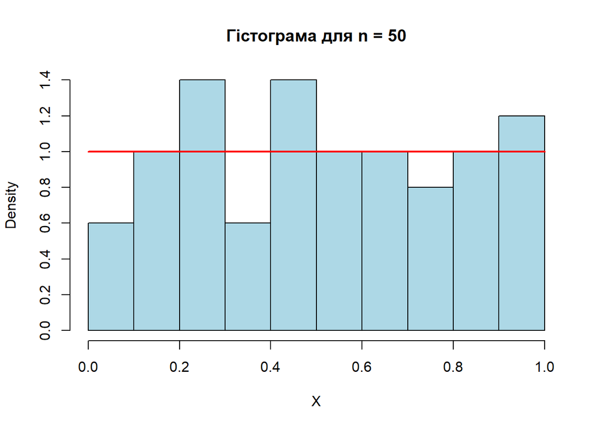

```r
# Гістограма для n = 50
hist(n50, prob = TRUE, main = "Гістограма для n = 50", xlab = "X", col = "lightblue", border = "black")
curve(dunif(x, min = 0, max = 1), col = "red", lwd = 2, add = TRUE)
```

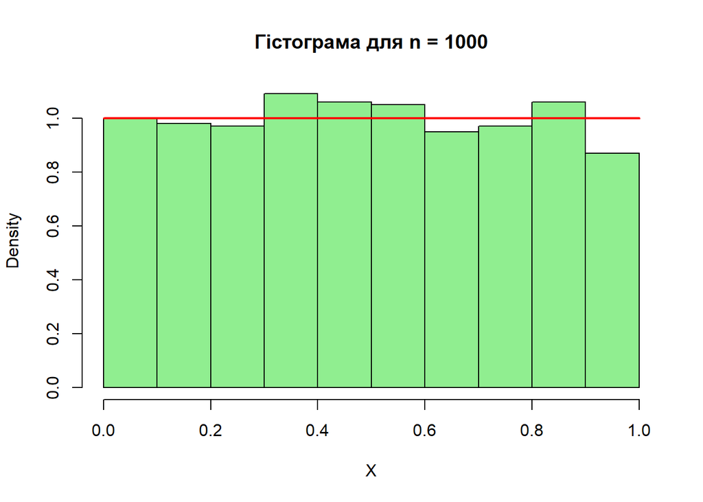

```r
# Гістограма для n = 1000
hist(n1000, prob = TRUE, main = "Гістограма для n = 1000", xlab = "X", col = "lightgreen", border = "black")
curve(dunif(x, min = 0, max = 1), col = "red", lwd = 2, add = TRUE)
```